# PII: 0304-405X(91)90021-B

#### 7. **Summary and conclusions**

Managers of domestic steel firms used a variety of approaches to help convince organized labor that their companies were in serious trouble, and therefore required major concessions. From the perspective of rank-and-file workers, the most convincing indication of serious trouble was probably the large-scale layoffs we document. We also find evidence that managers used reported losses and financial sacrifices by other (nonunion) stakeholders to support their case for labor concessions. Net income is materially lower during union negotiations than in other periods, when we control for cash flow performance. And although sample firms in the aggregate had positive cash flows in every year from 1980 to 1988, they reported losses in each of the years 1982-1986 and again in 1988. Importantly, the losses reported in union negotiation years are to a large degree driven by special earnings charges that reflect managers’ real restructuring decisions, but whose timing is discre- tionary across negotiation and nonnegotiation years. Controlling for company performance, salary plus bonus payments to CEOs (and to the five highest-paid executives) are significantly lower during union negotiations than for the same firms in other years. CEOs experienced an average 18.1% decline in salary plus bonus in union negotiation years, which contrasts markedly with their average increase of 19.5% in nonnegotia- tion years. For the five highest-paid executives, salary plus bonus declined an average 15.4% in union negotiation years, which compares with an average 16.0% increase in other years. Although managerial pay cuts are large in percentage terms (relative to the pay reductions of union and nonunion workers), their absolute magnitude is in the hundreds of thousands of dollars. The pervasive reductions in cash dividends we observe aggregate to the hundreds of millions. Both pale when compared with the billions of dollars in annual labor cost savings achieved through layoffs and wage reductions.

Reductions in the compensation paid top management - although small in relation to sample firms’ total labor cost savings - apparently serve as sym- bolic actions that help foster a general attitude that financial sacrifices are required by all stakeholders. Consistent with this view, white-collar pay cuts and reductions in cash dividends are substantial on a percentage basis, pervasive, and clustered during union negotiations. Analysis of top manage- ment’s public statements indicates they cited low (and diminished) earnings, dividend cuts and omissions, white-collar pay cuts and layoffs, and reductions in their own compensation to portray the firm as in serious financial difficulty, hence in need of substantial concessions from unionized labor. Overall, then, our evidence suggests that the corporate policies of domestic steel firms requesting labor concessions during the 1980s were determined by strategic contracting considerations as well as by the firm’s technological capabilities, product market pressures, etc.

#### *Chronology of union negotiations for the U.S. steel industry, 1980-1988*

This chronology was developed from information in *Standard & Poor’s Industry Surveys* and the *Wall Street Journal.* Each entry contains a brief description of the relevant union activity during a given month, sometimes taken verbatim from the *WSJ* article.

*February 1980:* The United Steel Workers (USW) open contract negotiations with the steel industry. *April 1980:* Contract negotiations are settled, with wage and benefit hikes that are estimated to increase labor costs by 37% over the next three years.

*July 1981:* Wheeling-Pittsburgh Steel is forced out of the Basic Industry Bargaining Group after negotiating a separate labor contract with the USW.

*June 1982:* USW local presidents authorize bargainers to begin informal talks with the industry even though the current labor contract is not set to expire until August 1, 1983. *July 1982:* Union negotiations break down. *November 1982:* Labor and management reach a tentative agreement, but their proposal fails to win the approval of local union presidents, raising the possibility of an industry-wide strike. *December 1982:* Wheeling-Pittsburgh Steel negotiates a 43-month labor contract at wage reductions of $3.65 per hour (over and above the $1.60 per hour reduction the firm had negotiated in 1981) in exchange for a promise to invest the labor cost savings in steel operations, 50% sharing of pretax profits after debt service charges and dividend payments, and the issuance of preferred stock to an employee trust fund.

*August 1984:* The steelmakers’ bargaining group begins to collapse, following National Steel’s announcement that it will bargain alone when the current contract expires in two years.

*April 1985:* Wheeling-Pittsburgh Steel files for bankruptcy. *May 1985:* The steel industry bargaining group collapses after a 30-year history. LTV an- nounces its intent to seek wage and benefit concessions from the USW. *September 1985:* LTV suspends dividends on four issues of preferred stock. *October* 1985: Bethlehem omits its dividend for the first time in 46 years and says it will seek to

restructure its agreement with the USW ‘well before’ the current contract expires next July 31

*January 1986:* LTV and Bethlehem begin separate negotiations with the USW on the contract set to expire August 1, 1986. *February 1986:* Armco, National, and Inland set late March target dates to negotiate new labor contracts. The USW defers scheduled wage increases for LTV, but not for Bethlehem and National. *March 1986:* LTV reaches a tentative agreement with the USW. Armco, National, and Bethlehem, discouraged over the terms of LTV’s labor pact and its uncertain ratification, abandon talks. Their concern is that, by negotiating first with the weakest steel producer, the USW has gained concessions that it can then impose on other steelmakers. Inland will keep bargaining. *April 1986:* Inland and the USW break off talks after failing to reach an agreement by the target deadline. The USW approves the contract with LTV, which provides for a $3.15 per hour reduction in labor costs with a payback schedule over time. *May 1986:* Bethlehem reaches a tentative accord with the union that will reduce labor costs by $1.97 per hour for one year. *June* 1986: U.S. Steel, the last of the major steel firms to negotiate with the USW, opens

bargaining talks. The USW approves the Bethlehem agreement. Inland Steel signs a tentative three-year pact that freezes wages, cuts benefits, and gives workers profit sharing. Armco extends the August 1 contract expiration date for three months. *July* 1986: LTV files for bankruptcy protection, and seeks additional concessions from the USW. The USW strikes one of the firm’s plants for a week to protest cancellation of retirees’ health and life insurance benefits until LTV reinstates them for six months. Bethlehem omits the dividend on two issues of preferred stock, citing the LTV bankruptcy filing. The Inland agreement receives final approval. U.S. Steel negotiations break down. *August 1986:* The USW strikes U.S. Steel. *September 1986:* Armco threatens to file for bankruptcy as local steelworkers strike the firm’s main plant in Middletown, Ohio. The company backs off its demands for wage concessions to settle the strike after five days with a new contract that provides only a wage and benefit freeze. Bankrupt LTV seeks to renegotiate its most recent pact with the union. *October 1986:* U.S. Steel resumes bargaining with the USW, as does Ammo. *November 1986:* Armco reaches agreement on a new labor contract that will vary from mill to mill. U.S. Steel breaks off contract talks.

Page 31

*January 1987:* U.S. Steel reopens union negotiations, and the strike ends. *February 1987:* The union ratifies a four-year contract with U.S. Steel that provides for wage reductions and profit sharing. *April 1987:* The USW agrees to negotiate a new labor agreement with LTV by May 1, terms to be retroactive to February 1. *May* 2987: The USW rejects a new pact with LTV, citing provisions that would eliminate jobs

and management’s failure to sacrifice as much as steelworkers have. *June 1987:* LTV and the USW resume talks, and reach tentative agreement. The Pension Benefit Guaranty Corporation threatens to return LTV’s pension obligations to the com- pany because the labor agreement restores certain supplemental pension benefits to the steelworkers, while the government continues to bear the bulk of LTV’s pension obligations, *August* 1987: The USW ratifies the new contract with LTV despite the PBGC’s continued legal

challenge.

#### *Employment changes and plant closures announced by the seuen major domes- tic steel producers, 1980-1988*

This appendix documents the net change in total employment (second column) during each of the years 1980-1988, as disclosed in the annual reports of the seven major domestic steel producers. If total employment figures are not disclosed, n.d. appears following the relevant year. Changes in total employment during union negotiation years are marked with an aster- isk. The text provides details of those changes, particularly plant closings, as reported in corporate annual reports, the *Wall Street Journal Index,* and referenced articles.

**Armco Inc.**

NOTE: contains mathematical notation; text above is the PDF text layer and symbols may be mis-extracted. Image shows the original.

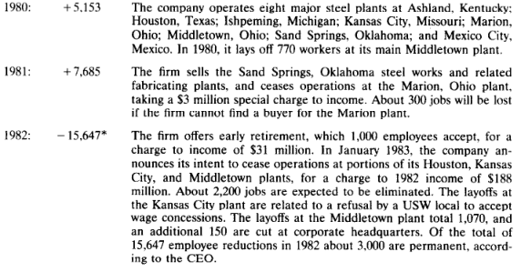

NOTE: complex table shown as an image of the PDF; the text below is a rough machine extraction and may be mis-aligned.

**extracted text (unreliable layout)**

1980: ; +5153 , ; The company operates eight major steel plants at Ashland , Kentucky; Houston, Texas; Ishpeming, Michigan; Kansas City, Missouri; Marion, Ohio; Middletown, Ohio; Sand Springs, Oklahoma; and Mexico City, Mexico. In 1980 it lays off 770 workers at its main Middletown plant , . | 1981: ; +7685 , ; The firm sells the Sand Springs, Oklahoma steel works and related fabricating plants, and ceases operations at the Marion, Ohio plant , taking a $3 million special charge to income. About 300 jobs will be lost if the firm cannot find a buyer for the Marion plant . | 1982: ; 15647* - , ; The firm offers early retirement , which 1 ,000 employees accept , for a charge to income of $31 million. In January 1983 , the company an- nounces its intent to cease operations at portions of its Houston, Kansas | ; ; City, and Middletown plants, for a charge to 1982 income of $188 million. About 2 ,200 jobs are expected to be eliminated . The layoffs at the Kansas City plant are related to a refusal by a USW local to accept wage concessions. The layoffs at the Middletown plant total 1 ,070 , and an additional 150 are cut at corporate headquarters. Of the total of 15 ,647 employee reductions in 1982 about 3 ,000 are permanent , accord - ing to the CEO .

[output not shown]

NOTE: table converted from PDF layout to HTML text; cell boundaries are reconstructed. See PDF if exact alignment matters.

| 1984: | - 1 ,400 | The salaried work force is reduced by 12% . The company sells the |
| --- | --- | --- |
|  |  | Seattle plant on December 31 . |
| 1985: | - 6 ,900* | The salaried work force is reduced by 20% The firm is attempting to . |
|  |  | narrow losses in its troubled bar, rod , and wire division by laying off |
|  |  | 45% of the salaried work force and 35% of the hourly workers. It will |
|  |  | close its Lebanon, Pennsylvania specialty steel plant idling 600 people. , |
|  |  | Earnings charges for discontinued operations related to steel production |
|  |  | are $87 .4 million. |
| 1986: | - 7 ,000 | The firm continues to lay off workers. It provides $28 .0 million for |
|  |  | discontinued steel operations, reducing its capacity from 17 .6 to 16 .0 |
|  |  | million tons, |
| 1987: | -3 ,100 | No layoffs or shutdowns are announced . |
| 1988: | - 1 ,500 | The company provides $113 .0 million for discontinued steel and steel- |
|  |  | related operations. Steelmaking capacity is 16 million tons, down from |
|  |  | 21 .5 million tons in 1980 . It now employs 32 ,900 workers, down from |
| Inland | Steel Company | 89 ,200 in 1980 . |
| 1980: | - 2 ,438 | Inland has one major steel producing facility, the Indiana Harbor Works |
|  |  | in East Chicago, Indiana, with 23 ,250 employees. The plant’s 1980 |
|  |  | steelworker layoffs peak at 2 ,900 in July. |
| 1981: | + 191 | The Melrose Park Illinois structural fabricating plant is closed in , |
|  |  | December, with no material earnings impact . The plant has 75 salaried |
|  |  | and 300 hourly workers; the former had been on strike as members of a |
|  |  | USW local . |
| 1982: | - 4 ,089* | The firm announces a number of temporary layoffs during the year. |
|  |  | About 10% of the total workforce is on layoff , with 5 ,200 of Inland’s |
|  |  | 18 ,000 union workers idle. About 450 salaried personnel take advantage |
|  |  | of an early retirement program, for a $9 .9 million earnings charge. |
| 1983: | - 2 ,305 | The company decides to close three raw materials facilities. The Jackson |
|  |  | City Iron Ore Company mine (shut down in April 1982) will be perma- |
|  |  | nently closed at an earnings charge of $15 .6 million. The Lancashire No. |
|  |  | 25 coal mine will be shut down, for a loss of 279 jobs and an earnings |
|  |  | charge of $36 .8 million. The firm is currently in negotiations to sell the |
|  |  | Bishop Coal Company, and is taking a $6 .0 million earnings charge for |
|  |  | idle costs expected to be incurred prior to sale. |
| 1984: | - 1 ,779 | The firm announces that it expects further across-the-board layoffs |
|  |  | (about 24% of its 15 ,166 hourly employees are currently idle) . It takes a |
|  |  | 1984 earnings charge of $28 .0 million for the planned reduction of 700 |
|  |  | salaried jobs (14%) during 1985 It anticipates the closing of older steel . |
|  |  | facilities over the next three years, for a 1984 earnings charge of $27 .0 |
|  |  | million. The firm provides an additional $10 .0 million to close part of its |
|  |  | ‘c’ Coke Battery complex (shut down since October 19831 and $7 .0 |
|  |  | million for idle costs and losses on sale of its Bishop Coal Company |
|  |  | (sold on December 31 , 19841 . |
| 1985: | - 2 ,508* | The firm announces it will shut down 30% of its capacity and lay off |
|  |  | another 900 hourly workers. It takes a $32 .0 million additional charge |
|  |  | for the closure of its ‘C’ Coke Battery complex. It also provides $18 .0 |
|  |  | million for reductions in its salaried work force for another 300 employ- |

NOTE: table converted from PDF layout to HTML text; cell boundaries are reconstructed. See PDF if exact alignment matters.

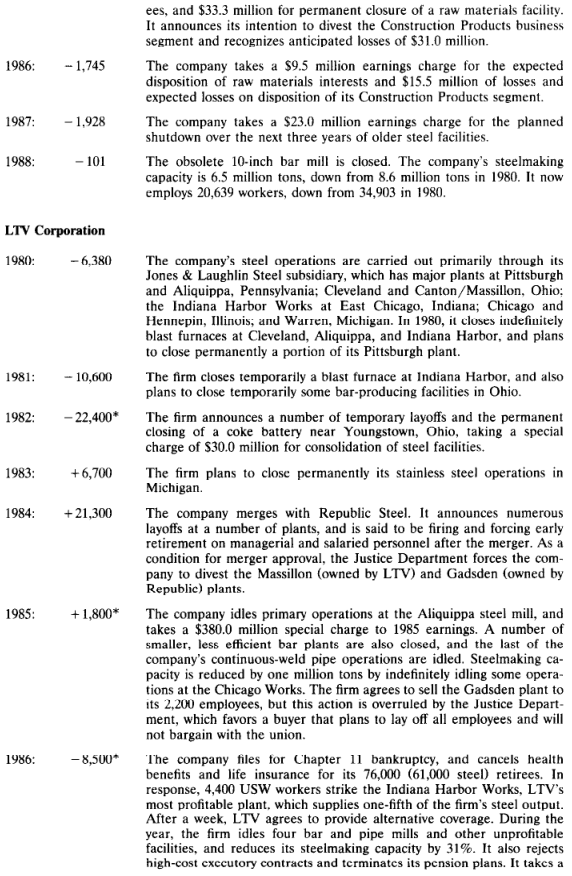

NOTE: complex table shown as an image of the PDF; the text below is a rough machine extraction and may be mis-aligned.

**extracted text (unreliable layout)**

; ; ees, and $33 .3 million for permanent closure of a raw materials facility. It announces its intention to divest the Construction Products business segment and recognizes anticipated losses of $31 .0 million. | 1986: ; 1745 - , ; The company takes a $9 .5 million earnings charge for the expected disposition of raw materials interests and $15 .5 million of losses and expected losses on disposition of its Construction Products segment . | 1987: ; 1928 - , ; The company takes a $23 .0 million earnings charge for the planned shutdown over the next three years of older steel facilities. | 1988: ; 101 - ; The obsolete lo-inch bar mill is closed The company’s steelmaking . | LTVCorporation ; ; capacity is 6 .5 million tons, down from 8 .6 million tons in 1980 . It now employs 20 ,639 workers, down from 34 ,903 in 1980 . | 1980: ; 6380 - , ; The company’s steel operations are carried out primarily through its Jones & Laughlin Steel subsidiary, which has major plants at Pittsburgh and Aliquippa, Pennsylvania; Cleveland and Canton/Massillon, Ohio: the Indiana Harbor Works at East Chicago, Indiana; Chicago and Henneoin. Illinois: and Warren. Michigan. In 1980 it closes indefinitelv . blast f&n&es at Cleveland Aliquippay and Indiana Harbor, and plans , to close permanently a portion of its Pittsburgh plant . | 1981: ; 10600 - , ; The firm closes temporarily a blast furnace at Indiana Harbor, and also plans to close temporarily some bar-producing facilities in Ohio. | 1982: ; 22400* - , ; The firm announces a number of temporary layoffs and the permanent closing of a coke battery near Youngstown, Ohio, taking a special charge of $30 .0 million for consolidation of steel facilities. | 1983: ; +6700 , ; The firm plans to close permanently its stainless steel operations in | ; ; Michigan. | 1984: ; +21300 , ; The company merges with Republic Steel . It announces numerous layoffs at a number of plants, and is said to be firing and forcing early retirement on managerial and salaried personnel after the merger. As a condition for merger approval , the Justice Department forces the com- pany to divest the Massillon (owned by LTV) and Gadsden (owned by Republic) plants. | 1985: ; +1800* , ; The company idles primary operations at the Aliquippa steel mill , and takes a $380 .0 million special charge to 198 .5 earnings. A number of smaller, less efficient bar plants are also closed , and the last of the company’s continuous-weld pipe operations are idled . Steelmaking ca- pacity is reduced by one million tons by indefinitely idling some opera- tions at the Chicago Works. The firm agrees to sell the Gadsden plant to its 2 ,200 employees, but this action is overruled by the Justice Depart- ment , which favors a buyer that plans to lay off all employees and will not bargain with the union. | 1986: ; 8500* - . ; The company files for Chapter 11 bankruptcy, and cancels health benefits and life insurance for its 76 ,000 (61 ,000 steel) retirees. In response, 4 ,400 USW workers strike the Indiana Harbor Works, LTV’s most profitable plant which supplies one-fifth of the firm’s steel output , . After a week , LTV agrees to provide alternative coverage. During the year, the firm idles four bar and pipe mills and other unprofitable facilities, and reduces its steelmaking capacity by 31% It also rejects . high -cost executory contracts and terminates its pension plans. It takes a

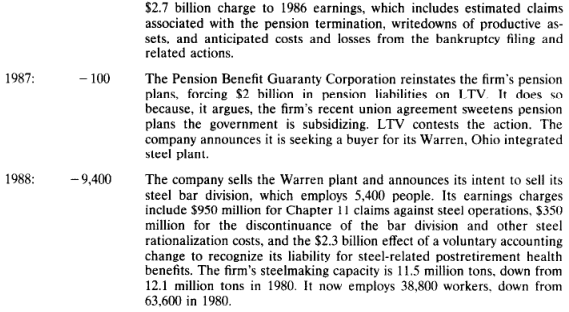

NOTE: complex table shown as an image of the PDF; the text below is a rough machine extraction and may be mis-aligned.

**extracted text (unreliable layout)**

; ; $2 .7 billion charge to 1986 earnings, which includes estimated claims | ; ; associated with the pension termination, writedowns of productive as- | ; ; sets, and anticipated costs and losses from the bankruptcy filing and | ; ; related actions. | 1987: ; - 100 ; The Pension Benefit Guaranty Corporation reinstates the firm’s pension | ; ; plans, forcing $2 billion in pension liabilities on LTV . It does so | ; ; because, it argues, the firm’s recent union agreement sweetens pension | ; ; plans the government is subsidizing. LTV contests the action. The | ; ; company announces it is seeking a buyer for its Warren, Ohio integrated | ; ; steel plant . | 1988: ; - 9 ,400 ; The company sells the Warren plant and announces its intent to sell its | ; ; steel bar division, which employs 5 ,400 people. Its earnings charges | ; ; include $950 million for Chapter 11 claims against steel operations, $350 | ; ; million for the discontinuance of the bar division and other steel | ; ; rationalization costs, and the $2 .3 billion effect of a voluntary accounting | ; ; change to recognize its liability for steel-related postretirement health | ; ; benefits. The firm’s steelmaking capacity is 11 .5 million tons, down from | ; ; 12 .1 million tons in 1980 . It now employs 38 ,800 workers, down from | ; ; 63 .600 in 1980 .

**Republic Steel Corporation** (merged with LTV Corporation in **1984)**

NOTE: contains mathematical notation; text above is the PDF text layer and symbols may be mis-extracted. Image shows the original.

| 1980: | - 1 ,944 | The company operates six steel plants, at Cleveland , Warren, and |
| --- | --- | --- |
|  |  | Canton, Ohio; Buffalo, New York; Chicago, Illinois; and Gadsden, |
|  |  | Alabama. In 1980 , the firm closes temporarily one of two blast furnaces |
|  |  | at Gadsden and one of three blast furnaces at Cleveland . |
| 1981: | + 14 .5 | No layoffs are announced . The company takes a $36 .0 million earnings |
|  |  | charge for idle facilities that are not expected to operate in the future. |
| 1982: | - 10 ,634* | The firm announces numerous layoffs, totaling 14 ,000 (over one-third of |
|  |  | the workforce) by the end of the year. Another 4 ,000 workers are on |
|  |  | short work weeks. It closes temporarily some operations at its Chicago |
|  |  | plant idling 2 ,000 workers, and shuts down two Cleveland bar mills and , |
|  |  | a coke plant in Buffalo, jointly owned with National Steel . Charges for |
|  |  | idle facilities total $25 .7 million. |
| 1983: | - 5 ,007 | Total layoffs reach 17 ,000 and are expected to continue. The company |
|  |  | takes an earnings charge of $194 .1 million for estimated plant shutdown |
|  |  | costs, primarily for facilities in Buffalo that it has already closed . |
| 1984: | n.d . | The company merges with LTV Corporation. At this time, the firm has |
|  |  | total productive capacity of 10 .9 million tons, down from 11 .1 million |
|  |  | tons in 1980 and 25 ,250 employees, down from 40 ,746 in 1980 , . |

NOTE: table converted from PDF layout to HTML text; cell boundaries are reconstructed. See PDF if exact alignment matters.

#### **National Steel Corporation**

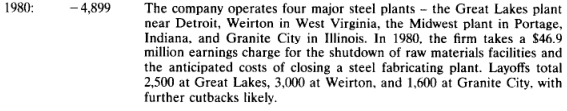

NOTE: complex table shown as an image of the PDF; the text below is a rough machine extraction and may be mis-aligned.

**extracted text (unreliable layout)**

1980: ; - ; 4899 , ; The company operates four major steel plants - the Great Lakes plant | ; ; ; near Detroit , Weirton in West Virginia, the Midwest plant in Portage, | ; ; ; Indiana, and Granite City in Illinois. In 1980 , the firm takes a $46 .9 | ; ; ; million earnings charge for the shutdown of raw materials facilities and | ; ; ; the anticipated costs of closing a steel fabricating plant . Layoffs total | ; ; ; 2 ,500 at Great Lakes, 3 ,000 at Weirton, and 1 ,600 at Granite City, with | ; ; ; further cutbacks likely.

| 38 | H DeAngelo and L DeAngelo, Restructuring of the steel industn . . |
| --- | --- |
| 1981: | - 880 The firm closes a second blast furnace at Weirton (the first was closed in |
|  | 19791 leaving two furnaces operating there. It also closes steel finishing , |
|  | facilities at the plant for one week . The company writes off equipment |
|  | and engineering costs of $16 .9 million. |
| 1982: | 6 ,122’ The firm offers the Weirton plant for sale to its employees, arguing this |
|  | step is necessary because this operation has the highest employment |
|  | costs in the steel industry and its 8 ,400 employees (plus 2 ,600 on layoff) |
|  | are unlikely to grant the wage concessions National estimates are |
|  | required to keep the plant operating. (To keep the USW from organiz- |
|  | ing Weirton, National has since the 1930s paid workers there about |
|  | $2 .00 more per hour than the average union wage.) The sale of Weirton |
|  | will reduce steelmaking capacity by about 2 .7 million tons. Although no |
|  | final agreement is reached , the company takes a $286 million charge to |
|  | 1982 earnings for the anticipated loss on the sale of Weirton. It also |
|  | takes a $190 million writeoff on raw materials facilities. During the year, |
|  | the firm announces several cutbacks and layoffs, and plans to close one |
|  | of two blast furnaces at Granite City for eight weeks. |
| 1983: | 7 ,154 The company sells the Weirton Steel Division (the transaction actually |
|  | closes in January 1984) , taking an additional $100 .0 million loss provi- |
|  | sion against 1983 earnings. It also takes a $55 .6 million writedown on |
|  | steel facilities. During 1983 , the company adopts a holding company |
|  | organizational structure. |
| 1984: | nd . The firm sells a 50% interest in its steel operations to Nippon Steel , |
|  | recognizing a $16 .9 million loss. |
| 1985: | n.d .* The firm announces plans to eliminate 2 ,500 hourly and salaried jobs, |
|  | cutting the work force by 20% Union officials indicate that they have . |
|  | been promised that the cuts will be made across-the-board in proportion |
|  | to the current ratios of salaried to hourly workers. |
|  | n.d . No layoffs or plant closings are announced . |
| 1987: | n.d . No layoffs or plant closings are announced . |
| 1988: | n.d The firm’s steelmaking capacity is about 7 .5 million tons, down from . |
|  | about 10 .1 million tons in 1980 . It now employs 19 ,621 workers, down |
|  | from 33 ,856 in 1980 . |

NOTE: table converted from PDF layout to HTML text; cell boundaries are reconstructed. See PDF if exact alignment matters.

| U .S Steel Corporation . |  |
| --- | --- |
| 1980: - 22 ,482 | The firm is the largest domestic integrated steel producer, with 21 major |
|  | plants in Alabama, Illinois, Indiana, Ohio, Pennsylvania, Texas, and |
|  | Utah including the Gary (Indiana) Works; the Lorain (Ohio) Works; , |
|  | the Edgar Thomson, Homestead , Clairton, and National Works near |
|  | Pittsburgh; South Works at Chicago, Illinois; and the Fairfield (Alabama) |
|  | Works. Just before the 1980 union negotiations, the firm takes an $808 .6 |
|  | million charge to 1979 earnings to close all or parts of 16 plants and |
|  | eliminate almost 13 ,000 jobs. It announces a number of layoffs during |
|  | the year, the largest of which is 3 ,000 people in the shutdown of most of |
|  | its Fairfield operations. |
| 1981: - 7 ,549 | The firm announces a number of one- and two-week closings, but no |
|  | large layoffs. |

NOTE: table converted from PDF layout to HTML text; cell boundaries are reconstructed. See PDF if exact alignment matters.

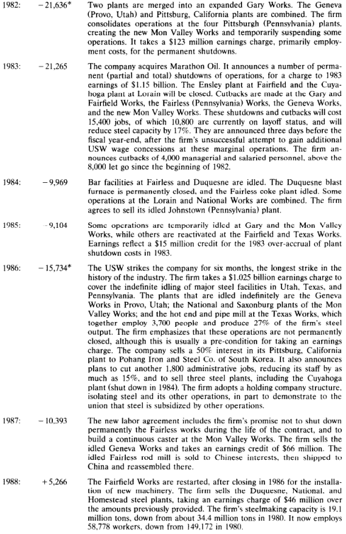

NOTE: complex table shown as an image of the PDF; the text below is a rough machine extraction and may be mis-aligned.

**extracted text (unreliable layout)**

1982: ; - 21 ,636* ; Two plants are merged into an expanded Gary Works. The Geneva | ; ; (Provo, Utah) and Pittsburg, California plants are combined . The firm | ; ; consolidates operations at the four Pittsburgh (Pennsylvania) plants, | ; ; creating the new Mon Valley Works and temporarily suspending some | ; ; operations. It takes a $123 million earnings charge, primarily employ- | ; ; ment costs, for the permanent shutdowns. | 1983: ; - 21 ,265 ; The company acquires Marathon Oil . It announces a number of perma- | ; ; nent (partial and total) shutdowns of operations, for a charge to 1983 | ; ; earnings of $1 .15 billion. The Ensley plant at Fairfield and the Cuya- | ; ; hoga plant at Lorain will be closed . Cutbacks are made at the Gary and | ; ; Fairfield Works, the Fairless (Pennsylvania) Works, the Geneva Works, | ; ; and the new Mon Valley Works. These shutdowns and cutbacks will cost | ; ; 15 ,400 jobs, of which 10 ,800 are currently on layoff status, and will | ; ; reduce steel capacity by 17% . They are announced three days before the | ; ; fiscal year-end after the firm’s unsuccessful attcmpt to gain additional , | ; ; USW wage concessions at these marginal operations. The firm an- | ; ; nounces cutbacks of 4 ,000 managerial and salaried personnel , above the | ; ; 8 ,000 let go since the beginning of 1982 . | 1984: ; - 9 ,969 ; Bar facilities at Fairless and Duquesne are idled . The Duquesne blast | ; ; furnace is permanently closed and the Fairless coke plant idled Some , . | ; ; operations at the Lorain and National Works are combined . The firm | ; ; agrees to sell its idled Johnstown (Pennsylvania) plant . | 1985: ; - 9 ,104 ; Some operations are temporarily idled at Gary and the Mon Valley | ; ; Works, while others are reactivated at the Fairfield and Texas Works. | ; ; Earnings reflect a $15 million credit for the 1983 over-accrual of plant | ; ; shutdown costs in 1983 . | 1986: ; - 15 ,734x ; The USW strikes the company for six months, the longest strike in the | ; ; history of the industry. The firm takes a $1 .025 billion earnings charge to | ; ; cover the indefinite idling of major steel facilities in Utah , Texas, and | ; ; Pennsylvania. The plants that are idled indefinitely are the Geneva | ; ; Works in Provo, Utah; the National and Saxonburg plants of the Mon | ; ; Valley Works; and the hot end and pipe mill at the Texas Works, which | ; ; together employ 3 ,700 people and produce 27% of the firm’s steel | ; ; output . The firm emphasizes that these operations are not permanently | ; ; closed , although this is usually a pre-condition for taking an earnings | ; ; charge. The company sells a 50% interest in its Pittsburg, California | ; ; plant to Pohang Iron and Steel Co. of South Korea. It also announces | ; ; plans to cut another 1 ,800 administrative jobs, reducing its staff by as | ; ; much as 15% , and to sell three steel plants, including the Cuyahoga | ; ; plant (shut down in 1984) . The firm adopts a holding company structure, | ; ; isolating steel and its other operations, in part to demonstrate to the | ; ; union that steel is subsidized by other operations. | 1987: ; - 10 ,393 ; The new labor agreement includes the firm’s promise not to shut down | ; ; permanently the Fairless works during the life of the contract and to , | ; ; build a continuous caster at the Mon Valley Works. The firm sells the | ; ; idled Geneva Works and takes an earnings credit of $66 million. The | ; ; idled Fairless rod mill is sold to Chinese interests, then shipped to | ; ; China and reassembled there. | 1988: ; + 5 ,266 ; The Fairfield Works are restarted , after closing in 1986 for the installa- | ; ; tion of new machinery. The firm sells the Duquesne, National , and | ; ; Homestead steel plants, taking an earnings charge of $46 million over | ; ; the amounts previously provided The firm’s steelmaking capacity is 19 .1 . | ; ; million tons, down from about 34 .4 million tons in 1980 . It now employs | ; ; 58 ,778 workers, clown from 149 .172 in 1980 .

#### **Appendix C**

*Wage and benefit reductions for top management and other salaried personnel in the U.S. steel industry, 1980-1988*

This chronology was developed from information in the *Wall Street Journal.* Each entry contains a brief description of the relevant *WSJ* article, often taken verbatim from the article.

Armco Inc.

*4/26/82*

*l/26/82*

*4/25/83*

At the annual meeting, CEO Holiday says financial results this year probably will result in a sharp reduction or elimination of executive bonuses for 1982, and total executive compensation will be cut by 30% to 35%.

The company freezes merit raises and eliminates most bonuses for salaried employ- ees, cutting their total compensation by 15% to 30%.

At the annual meeting, CEO Holiday, apparently anticipating a hostile stockholder reaction to the latest dividend cut (the third in less than a year), tells stockholders that executive compensation for 1982 was down 44% from 1981 levels. He also says the company has suspended all contributions to the employee savings plan for all nonunion, salaried employees, and will try to negotiate a similar arrangement with employees represented by local unions.

**Bethlehem Steel Corp.**

**6/16/82** The firm will reduce salaries of 250 high-level managers by 5% (10% for those who are both officers and directors) beginning July 1. The company also said that it probably won’t pay any bonuses this year. The reduction in total managerial compensation will be about 28% for top executives and 14% for other officers. The firm cites severe economic and competitive conditions, but some analysts see the move as a prelude to a dividend cut and as posturing before the steel industry’s labor talks start.

l/7/82 The firm announces reductions in its compensation program for 22,000 salaried workers, including 10% cuts in nonofficer directors’ fees.

8/10/82 The firm will change its compensation and benefits program for all salaried employ- ees, reducing paid time off, pension, savings, and medical benefits, and instituting an all-merit compensation program.

l/21/83 The firm will again cut the pay of more than 14,000 salaried and nonunion employees, this time by 2.5% to 8%. This action follows a similar move earlier in the week by U.S. Steel, and comes as the industry is entering a third round of bargaining with the USW.

9/30/85 The firm will further reduce wages and benefits for 10,000 salaried workers. The cuts include a 10% salary reduction for upper management, a 5% reduction in the salaries of all other salaried employees, and the elimination of the dental plan. The chairman indicates that similar contributions by hourly employees are needed to help return the firm to profitability and to help provide employment security for as many people as possible.

12/18/85 The firm scales back retirement benefits for 10,000 salaried nonunion employees. The chairman indicates that hourly workers will be expected to make similar concessions in the upcoming union negotiations (opened on l/22/86).

*5/21/86* Article reports white- and blue-collar workers’ resentment of CEO Trautlein who, along with other top managers, received a generous salary increase and golden parachute for 1985. White-collar workers have received pay cuts in three of the last four years, and the disclosure of their anger at management apparently contributed to last month’s breakdown in union negotiations. Mr. Trautlein announced his retirement (at age 59) last month.

#### **Inland Steel Company**

*4/29/82* At the annual meeting, the firm announces that it is reducing the pay of about 400 executives and halving the dividend on common stock. It is also freezing the wages of many office employees, and will seek early retirement from others.

#### *12/16/82*

#### *l/31 /83*

The firm is granting smaller bonuses to salaried employees this year, but the USW is angry nonetheless because bonuses will not be eliminated. A company spokesperson justifies the action by noting that salaried workers didn’t receive merit increases this year, were denied a cost-of-living adjustment, and had medical benefits reduced. A union spokesperson says the bonuses are ‘going to make us take a long, hard look at the company’s contract proposals next year (the current contract expires July 31). If they have such a severe cash flow problem, how can they afford to give bonuses to salaried personnel?’

The firm permanently discontinues cost-of-living adjustments and eliminates two paid holidays for 5,600 salaried workers.

LTV **Corporation**

NOTE: contains mathematical notation; text above is the PDF text layer and symbols may be mis-extracted. Image shows the original.

5/22/85

S/30/85

l/6/86

7/18,/86

4/13/87

Article notes that LTV loaned its CEO an interest-free $1 million so he could exercise expiring stock options. The USW is infuriated, given that the loan was made in a year in which LTV had a record $378.2 million loss and that the firm has labeled recent layoffs ‘temporary’ to avoid having to pay severance benefits to union workers. The amount of the loan would have been sufficient to prevent the loss of more than 600 jobs, according to a union spokesperson.

The firm’s troubled steel unit will cut the pay of 8,000 salaried employees, effective September 1. It will also reduce a number of benefits, including vacation days and overtime. One industry source says that LTV has also drawn up a shopping list of concessions it hopes to obtain from unionized workers (union negotiations are expected to begin in December).

Chairman Hay promises further cuts in pay, benefits, and employees at corporate headquarters, and says that he himself has volunteered for a 25% pay cut.

LTV files for bankruptcy protection, and says it will seek further labor cost reductions from employees.

WSJ article reveals that the firm paid its top executives almost $1 million in performance-related compensation in 1986, the year it filed for bankruptcy protec- tion and negotiated labor givebacks. One month later, the union rejected the latest labor agreement, in part because it believes managers haven’t shouldered as much financial sacrifice as the firm’s 23,000 steelworkers.

**Republic Steel Corporation** (merged with LTV Corporation in 1984)

NOTE: contains mathematical notation; text above is the PDF text layer and symbols may be mis-extracted. Image shows the original.

4/21/82 The firm says it is suspending cost-of-living raises for all salaried employees, effective this month.

7/?/82 The company installs a freeze on merit pay increases (exact date of article unknown, reference is in 8/26/82 article).

*8/26/82* The firm will cut salaries 7% to 10% for 5,800 employees. Officers’ pay cuts will be lo%, while those for supervisory and other salaried workers will be 7%. Manage- ment incentive plans, savings and investment plans, and some paid holidays were previously cut, reducing compensation of management personnel by an average of 18%.

**National Steel Corp.**

8/21/80

3/16/82

10/13/82

3/2/83

3/21/83

The firm cuts the dividend, noting that revenues are inadequate for the current adverse conditions, despite the firm’s cost-cutting actions, which include a reduction in all officers’ salaries. National has been especially hard hit because its product mix is tilted heavily toward flat-rolled steel for the automobile industry, which is experiencing a strong downturn.

The firm, expecting a first-quarter loss, is freezing the pay of its 7,000 salaried workers and cutting the pay of senior management by 10% to 25%. It also is discontinuing cost-of-living adjustments for salaried personnel, reducing contribu- tions to the employee stock investment plan, and eliminating some vacation benefits.

The firm will temporarily reduce base salaries by 10% for 6,000 nonunion, salaried employees, and will reinstate them ‘as soon as business conditions permit’. The cuts apply to personnel in all operating units and at company headquarters, but not to those at the firm’s financial services subsidiary.

The USW ratifies the new labor contract for the steel industry.

The firm cancels the previously-announced 10% salary reduction for nonunion personnel, but will still cut fringe benefits. A company spokesperson says: ‘The changes are being made to bring the levels of sacrifice closer to those being made by our hourly workers, and they also expand and make permanent labor cost savings for the present and long term.’

#### **U.S. Steel Corporation**

**5/20/80** The firm institutes a freeze on managerial (at all ranks) pay less than a month after the completion of union negotiations that granted double-digit wage increases to steelworkers.

3/12/81 The firm seeks shareholder approval to eliminate the effect of such unusual events as plant closings and asset sales on top management’s incentive compensation.

6/22/82 The firm will cut compensation benefits of about 27,000 management and salaried employees. Wages are to be cut by at least 5%, with managerial personnel suffering cuts of up to 30% because their incentive compensation will be suspended for 1982. (Incentive pay totaled $3.4 million in 1981.) This announcement is seen as tactical posturing by the steel industry, which is preparing to ask the USW for wage and benefit concessions.

l/17/83 The firm says it expects to report a ‘staggering’ fourth-quarter loss and will cut the pay of 28,000 management, salaried, and nonunion hourly workers by 5%. The timing of the second nonunion pay cut in seven months is seen as a move to strengthen the industry’s position when it again asks the USW next month for steep pay and benefit concessions. Chairman Roderick alleges that only the USW has refused to contribute to the sacrifices made by everyone else in the steel family to ensure the survival of the company.

8/12/86

3/13,‘87

USX plans to extend (previously announced: date unknown) pay cuts to its Marathon Oil and Texas Oil & Gas units. The cuts, said to be 12% for top officials and 6% for lower-level managers, follow similar cuts for its corporate staff and steelmaking and diversified business units.

USX discloses that top management took pay cuts of about 25% in 1986 as a result of a series of austerity measures adopted when the USW struck the firm in August. However, they also received golden parachutes that would pay as much as three times their salaries plus incentive bonuses if they lost their jobs following a hostile takeover.

#### **References**

Bowen, Robert M., David Burgstahler, and Lane A. Daley, 1986, Evidence on the relationship

between earnings and various measures of cash flow, The Accounting Review LXI, 713-725. DeAngelo, Harry and Linda DeAngelo, 1990, Dividend policy and financial distress: An empirical investigation of troubled NYSE firms, Journal of Finance 45, 1415-1431. Elliott, John A. and Wayne H. Shaw, 1988, Write-offs as accounting procedures to manage perceptions, Journal of Accounting Research 26, 91-119. Fruhan, William E., Jr., 1985, Management, labor, and the golden goose, Harvard Business Review, Sept.-Oct., 131-141. Hoerr, John P., 1988, And the wolf finally came: The decline of the american steel industry

(University of Pittsburgh Press, Pittsburgh, PA). Jensen, Michael C. and Kevin J. Murphy, 1990a, CEO incentives - it’s not how much you pay,

but how, Harvard Business Review, May-June, 138-153. Jensen, Michael C. and Kevin J. Murphy, 1990b, Performance pay and top-management incentives, Journal of Political Economy 98, 225-264. Jones. Jennifer, 1990, Earnings management during import relief investigations. Unpublished working paper (University of Chicago, Chicago, IL). Liberty, Susan E. and Jerold L. Zimmerman, 1986, Labor union contract negotiations and accounting choice, The Accounting Review LXI, 692-712. Strong, John S. and John R. Meyer, 1987, Asset writedowns: Managerial incentives and security

returns, Journal of Finance 42, 643-663.